# BST260 Final Project XB Machine Learning Section

Xiang Bai

12/3/2021

### Load Libraries

```r
#libraries
library(dplyr)
library(stringr)
library(tidyverse)
library(RCurl)
library(httr)
library(caret)
library(ggplot2)
library(mlbench)
library(Boruta)
library("DataExplorer")
library(ggstatsplot)
library(ggcorrplot)
library(lares)
library(randomForest)
library("faux")
library(skimr)
library(nnet)
library(e1071)
library(glmnet)
set.seed(260)
```

## Load Preprocess data

```r
df_complete = read.csv("./Data/aggregate_pm_census_cdc.csv")
dim(df_complete) # shape of data
```

```
## [1] 3105   47
```

```r
head(df_complete,3) # brief look at data
```

```
##   fips mean_pm25 mean_winter_temp mean_summer_temp mean_winter_rm
## 1 1001 10.376526         288.0851         306.0235       85.65184
## 2 1003  9.272959         290.2089         305.5166       89.73097
## 3 1005  9.636003         289.2421         306.0622       88.63357
##   mean_summer_rm  Admin2 Province_State Country_Region         Last_Update
## 1       96.05542 Autauga        Alabama             US 2021-11-01 04:22:01
## 2       97.97154 Baldwin        Alabama             US 2021-11-01 04:22:01
## 3       97.37167 Barbour        Alabama             US 2021-11-01 04:22:01
##        Lat     Long_ Confirmed Deaths Recovered Active         Combined_Key
## 1 32.53953 -86.64408     10252    148        NA     NA Autauga, Alabama, US
## 2 30.72775 -87.72207     37414    555        NA     NA Baldwin, Alabama, US
## 3 31.86826 -85.38713      3601     76        NA     NA Barbour, Alabama, US
##             NAME land_area year hispanic_pct   poverty poverty_mcare population
## 1 Autauga County  594.4437 2016   0.02572254 0.1226602    0.06304520      55049
## 2 Baldwin County 1589.7937 2016   0.04366698 0.1299380    0.07115799     199510
```

[output cut: 17 more lines]

```r
names(df_complete) # all included variables
```

```
##  [1] "fips"                    "mean_pm25"
##  [3] "mean_winter_temp"        "mean_summer_temp"
##  [5] "mean_winter_rm"          "mean_summer_rm"
##  [7] "Admin2"                  "Province_State"
##  [9] "Country_Region"          "Last_Update"
## [11] "Lat"                     "Long_"
## [13] "Confirmed"               "Deaths"
## [15] "Recovered"               "Active"
## [17] "Combined_Key"            "NAME"
## [19] "land_area"               "year"
## [21] "hispanic_pct"            "poverty"
## [23] "poverty_mcare"           "population"
## [25] "median_house_value"      "blk_pct"
## [27] "white_pct"               "native_pct"
## [29] "asian_pct"               "no_grad"
## [31] "no_grad_mcare"           "median_household_income"
## [33] "owner_occupied"          "median_age"
## [35] "age_pct_0_14"            "age_pct_15_44"
## [37] "age_pct_45_65"           "age_pct_65_plus"
## [39] "population_density"      "q_popdensity"
## [41] "obese"                   "smoke"
## [43] "Population"              "older_pecent"
## [45] "young_pecent"            "prime_pecent"
## [47] "mid_pecent"
```

There are a total of 47 variables in this data that was combined from [multiple sources](https://github.com/steventang26/BST260-Final-Project/blob/master/README.md). Of this data there are over 3000 counties and resulting dependent variables–which we are looking at either COVID cases or COVID deaths.

```r
# drop all repeated variables and keep wanted
# keep Population as the correct variable
todrop = c("fips","Admin2","Active", "q_popdensity","Last_Update", "year", "Country_Region", "NAME", "population", "poverty_mcare", "Recovered")


df_prelim <- df_complete %>%
  select(-todrop) %>%
  subset(Province_State != "Utah") %>%
  rename_all(recode, Combined_Key = "County") %>%
  remove_rownames %>%
  column_to_rownames(var = "County") %>%
  select(-Province_State) %>% # Utah reported no cases or deaths info
  mutate(Mortality = (Deaths / (Population / 100000)))
```

```
## Note: Using an external vector in selections is ambiguous.
## ℹ Use `all_of(todrop)` instead of `todrop` to silence this message.
## ℹ See <https://tidyselect.r-lib.org/reference/faq-external-vector.html>.
```

```r
glimpse(df_prelim)
```

```
## Rows: 3,079
## Columns: 35
## $ mean_pm25               <dbl> 10.376526, 9.272959, 9.636003, 10.726068, 10.6…
## $ mean_winter_temp        <dbl> 288.0851, 290.2089, 289.2421, 287.3628, 285.56…
## $ mean_summer_temp        <dbl> 306.0235, 305.5166, 306.0622, 305.9822, 305.17…
## $ mean_winter_rm          <dbl> 85.65184, 89.73097, 88.63357, 86.48587, 85.449…
## $ mean_summer_rm          <dbl> 96.05542, 97.97154, 97.37167, 96.29308, 94.630…
## $ Lat                     <dbl> 32.53953, 30.72775, 31.86826, 32.99642, 33.982…
## $ Long_                   <dbl> -86.64408, -87.72207, -85.38713, -87.12511, -8…
## $ Confirmed               <int> 10252, 37414, 3601, 4279, 10406, 1526, 3351, 2…
## $ Deaths                  <int> 148, 555, 76, 87, 178, 44, 96, 495, 143, 61, 1…
## $ land_area               <dbl> 594.4437, 1589.7937, 885.0020, 622.4614, 644.8…
## $ hispanic_pct            <dbl> 0.025722538, 0.043666984, 0.043097618, 0.02223…
## $ poverty                 <dbl> 0.1226602, 0.1299380, 0.2637367, 0.1645391, 0.…
## $ median_house_value      <dbl> 141000, 173400, 90300, 97200, 124200, 68000, 8…
```

[output cut: 22 more lines]

### Exploratory Data Analysis

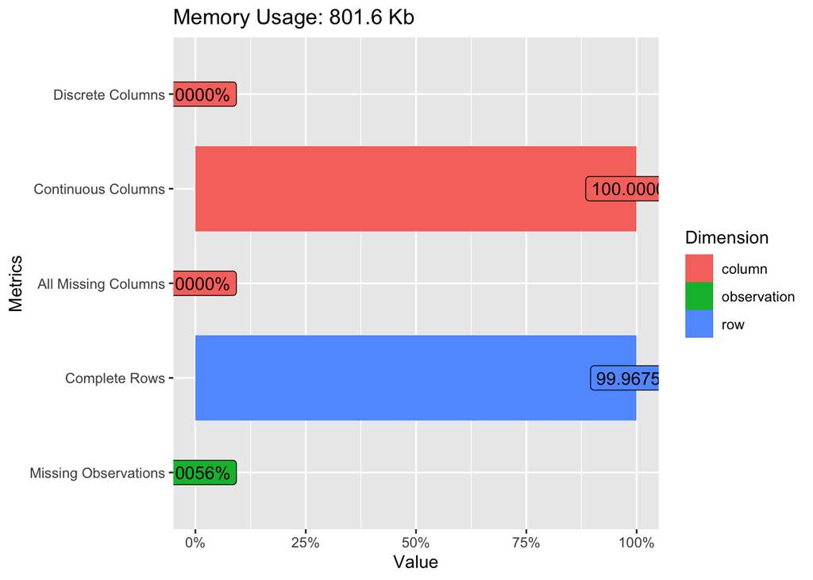

```r
#states = rownames(df[which(df["Deaths"] > 10000),]) #points to label
#rownames(df[states,])

plot_intro(df_prelim) # shows data.nas
```

```r
#ggstatsplot::ggcorrmat(
#  data = df,
#  type = "parametric",
#  colors = c("darkred", "white", "steelblue")) # change default colors

## too many variables in ugly correlation plot

  #geom_text(label = rownames(df[states,]))
```

```r
# dropping these variabls as redundant with age_pct variables avoid collinearity
todropmore = c("mid_pecent", "prime_pecent", "older_pecent" ,"young_pecent", "Deaths")

desvars <- c("Mortality", "mean_pm25", "smoke", "obese", "poverty", "no_grad", "owner_occupied", "hispanic_pct", "blk_pct", "age_pct_65_plus", "age_pct_45_65", "age_pct_15_44", "population_density", "median_household_income", "median_house_value", "mean_summer_temp", "mean_winter_temp", "mean_summer_rm", "mean_winter_rm")


df <- df_prelim %>%
  select(-todropmore) %>%
  select(desvars)
```

```
## Note: Using an external vector in selections is ambiguous.
## ℹ Use `all_of(todropmore)` instead of `todropmore` to silence this message.
## ℹ See <https://tidyselect.r-lib.org/reference/faq-external-vector.html>.
```

```
## Note: Using an external vector in selections is ambiguous.
## ℹ Use `all_of(desvars)` instead of `desvars` to silence this message.
## ℹ See <https://tidyselect.r-lib.org/reference/faq-external-vector.html>.
```

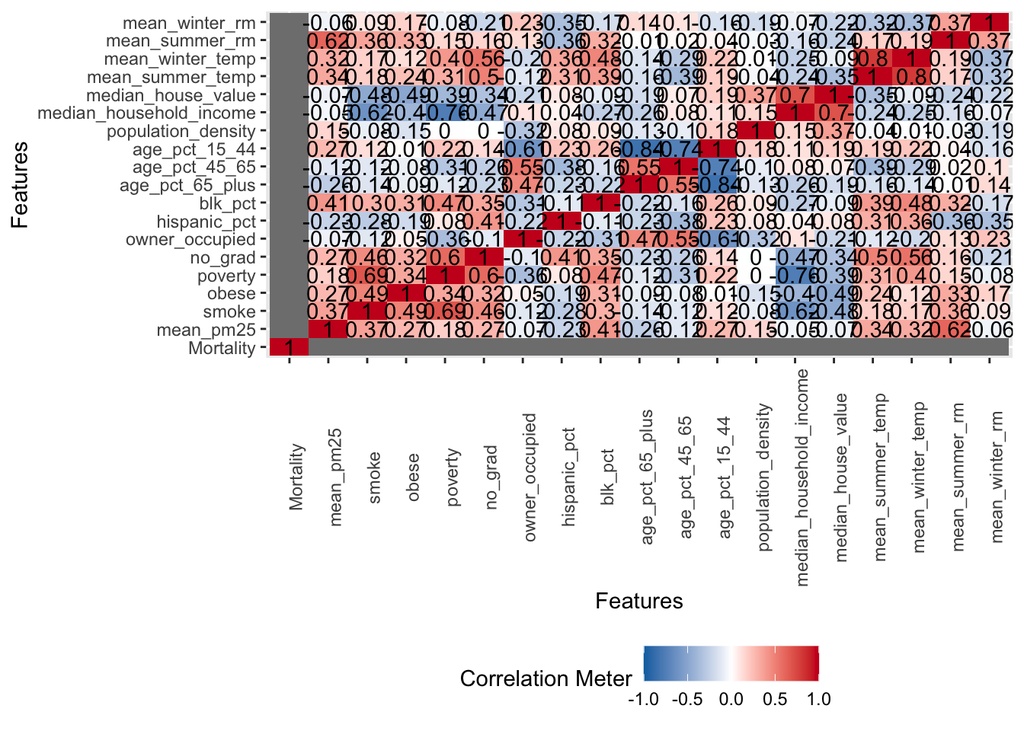

```r
plot_correlation(df)
```

```r
# Picture of Variables
skimmed <- skim_to_wide(df)
skimmed[, c(1,2,4,5,8:12)]
```

Data summary

| Name | .data |
| --- | --- |
| Number of rows | 3079 |
| Number of columns | 19 |
| _______________________ |  |
| Column type frequency: |  |
| numeric | 19 |
| ________________________ |  |
| Group variables | None |

**Variable type: numeric**

| skim_variable | complete_rate | mean | p25 | p50 | p75 | p100 | hist |
| --- | --- | --- | --- | --- | --- | --- | --- |
| Mortality | 1 | 14.90 | 9.96 | 14.14 | 19.10 | 57.43 | ▅▇▂▁▁ |
| mean_pm25 | 1 | 7.89 | 6.21 | 8.39 | 9.56 | 12.73 | ▁▃▅▇▁ |
| smoke | 1 | 0.18 | 0.15 | 0.17 | 0.20 | 0.41 | ▃▇▂▁▁ |
| obese | 1 | 0.33 | 0.29 | 0.33 | 0.37 | 0.58 | ▁▅▇▁▁ |
| poverty | 1 | 0.16 | 0.12 | 0.16 | 0.20 | 0.54 | ▃▇▂▁▁ |
| no_grad | 1 | 0.21 | 0.17 | 0.20 | 0.25 | 0.55 | ▂▇▃▁▁ |
| owner_occupied | 1 | 0.71 | 0.67 | 0.73 | 0.77 | 0.92 | ▁▁▂▇▂ |
| hispanic_pct | 1 | 0.09 | 0.02 | 0.04 | 0.09 | 0.99 | ▇▁▁▁▁ |
| blk_pct | 1 | 0.09 | 0.01 | 0.02 | 0.11 | 0.86 | ▇▁▁▁▁ |
| age_pct_65_plus | 1 | 0.18 | 0.15 | 0.17 | 0.20 | 0.53 | ▂▇▁▁▁ |
| age_pct_45_65 | 1 | 0.28 | 0.26 | 0.28 | 0.29 | 0.47 | ▁▁▇▁▁ |
| age_pct_15_44 | 1 | 0.36 | 0.33 | 0.36 | 0.39 | 0.67 | ▁▇▆▁▁ |
| population_density | 1 | 271.71 | 17.80 | 45.76 | 118.12 | 72163.70 | ▇▁▁▁▁ |
| median_household_income | 1 | 47702.24 | 39567.50 | 46130.00 | 53477.50 | 125672.00 | ▃▇▁▁▁ |
| median_house_value | 1 | 135173.86 | 87850.00 | 113800.00 | 156950.00 | 966600.00 | ▇▁▁▁▁ |
| mean_summer_temp | 1 | 303.14 | 300.86 | 303.30 | 305.83 | 313.87 | ▁▂▇▆▁ |
| mean_winter_temp | 1 | 280.44 | 275.12 | 280.18 | 285.61 | 298.34 | ▂▇▇▆▁ |
| mean_summer_rm | 1 | 89.31 | 88.21 | 91.36 | 94.84 | 99.78 | ▁▁▁▁▇ |
| mean_winter_rm | 1 | 87.50 | 85.14 | 88.05 | 90.77 | 97.67 | ▁▁▂▇▅ |

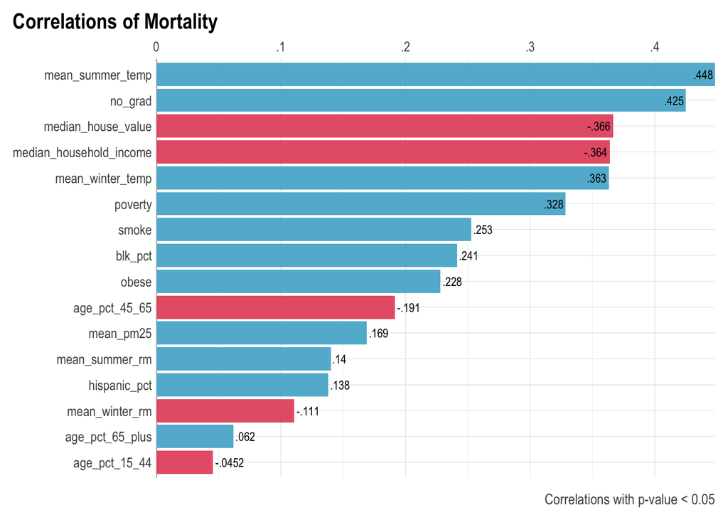

```r
#ggplot(df, aes(x = Confirmed, y = Deaths)) +
#  geom_point(size = 1) +
#  scale_x_log10() +
#  scale_y_log10() ## not a meaningful plot

#corr_cross(df,
#  max_pvalue = 0.05, # display only significant correlations (at 5% level)
#  top = 15)

# highest correlations with COVID death Mortalitys
corr_var(df, # name of dataset
  Mortality, # name of variable to focus on
  top = 20, # display top 5 correlations
  max_pvalue = 0.05)
```

```r
#find cases with NAs
df_missing = df[!complete.cases(df), ]
df_missing #showing rows
```

```
##                                 Mortality mean_pm25     smoke obese  poverty
## Oglala Lakota, South Dakota, US        NA  4.303522 0.3782224 0.395 0.539496
##                                   no_grad owner_occupied hispanic_pct
## Oglala Lakota, South Dakota, US 0.3273608      0.5344475   0.03463507
##                                    blk_pct age_pct_65_plus age_pct_45_65
## Oglala Lakota, South Dakota, US 0.00238379      0.06310033      0.185515
##                                 age_pct_15_44 population_density
## Oglala Lakota, South Dakota, US     0.4362336           6.812663
##                                 median_household_income median_house_value
## Oglala Lakota, South Dakota, US                   26330              19800
##                                 mean_summer_temp mean_winter_temp
## Oglala Lakota, South Dakota, US         303.5243         277.0423
##                                 mean_summer_rm mean_winter_rm
## Oglala Lakota, South Dakota, US       84.81005       89.94799
```

```r
# removed 1 county with no smoke data
df <- df[!(row.names(df) %in% "Oglala Lakota, South Dakota, US"), ]
```

Preliminary look shows that interestingly PM2.5 values, age above 65yo, and smoking have fairly low correlations with COVID death rates.

### Machine Learning Analysis:`Support Vector Regression`

```r
#split again with deaths variable
index_train<- createDataPartition(y = df$Mortality, times =1, p=0.8, list = FALSE)
train_set <- slice(df, index_train)
test_set <- slice(df, -index_train)

dim(train_set)
```

```
## [1] 2464   19
```

```r
dim(test_set)
```

```
## [1] 614  19
```

```r
## Trying SVR Model
#Regression with SVM
#with top 10 correlated
modelsvm = svm(log(1 + Mortality) ~ mean_summer_temp + no_grad + median_house_value + median_household_income+ mean_winter_temp+ poverty+ smoke+ blk_pct+ obese+ age_pct_45_65+ mean_pm25, train_set, preProcess = c("center","scale"))
#all variables
modelsvm2 = svm(log(1 + Mortality) ~ ., train_set, preProcess = c("center","scale"))

#Predict using SVM regression
predYsvm = predict(modelsvm, test_set)
predYsvm2 = predict(modelsvm2, test_set)

summary(modelsvm)
```

```
##
## Call:
## svm(formula = log(1 + Mortality) ~ mean_summer_temp + no_grad + median_house_value +
##     median_household_income + mean_winter_temp + poverty + smoke +
##     blk_pct + obese + age_pct_45_65 + mean_pm25, data = train_set,
##     preProcess = c("center", "scale"))
##
##
## Parameters:
##    SVM-Type:  eps-regression
##  SVM-Kernel:  radial
##        cost:  1
##       gamma:  0.09090909
##     epsilon:  0.1
##
##
## Number of Support Vectors:  2085
```

```r
summary(modelsvm2)
```

```
##
## Call:
## svm(formula = log(1 + Mortality) ~ ., data = train_set, preProcess = c("center",
##     "scale"))
##
##
## Parameters:
##    SVM-Type:  eps-regression
##  SVM-Kernel:  radial
##        cost:  1
##       gamma:  0.05555556
##     epsilon:  0.1
##
##
## Number of Support Vectors:  2055
```

```r
#W = t(modelsvm$coefs) %*% modelsvm$SV
#b = modelsvm$rho

## RMSE for SVR Model

#Calculate RMSE
RMSEsvm=rmse(predYsvm,log(1 + test_set$Mortality))
RMSEsvm2=rmse(predYsvm2, log(1 + test_set$Mortality))
RMSEsvm
```

```
## [1] 0.4235276
```

```r
RMSEsvm2
```

```
## [1] 0.4099007
```

```r
R2(predYsvm, log(1 + test_set$Mortality))
```

```
## [1] 0.3826659
```

```r
R2(predYsvm2,log(1 + test_set$Mortality))
```

```
## [1] 0.4233645
```

```r
## Tuning SVR model by varying values of maximum allowable error and cost parameter

#Tune the SVM model
#OptModelsvm = tune(svm, Mortality ~ ., data = train_set, ranges=list(elsilon=seq(0,1,0.2), cost = 1:10), preProcess = c("center","scale"))

#tunedmodels = tune.svm(Mortality ~ ., data= train_set, kernel="linear", cost=c(0.001, 0.01, 0.1, 1, 5), preProcess = c("center","scale"))

#Print optimum value of parameters
#print(tunedmodels)

#Plot the performance of SVM Regression model
#plot(tunedmodels)

#Find out the best model
# Bestmodel = tunedmodels$best.model

#Predict Y using best model
# PredYBst=predict(Bestmodel,test_set)

#Calculate RMSE of the best model
#RMSEBst=rmse(PredYBst,test_set$Mortality)
#RMSEBst #better RMSE value than untuned model
#R2(PredYBst,test_set$Mortality)
```

## Regression with `LASSO`

```r
# determine the variables to run on
# What if running through LASSO

# Independent Variables
x <- df %>%
  select(-Mortality) %>%
  as.data.frame()
# Target variable
y <- df$Mortality
# Training: 80%; Test: 20%
set.seed(260)
inTrain <- createDataPartition(y, p = .80, list = FALSE)[,1]
x_train <- x[ inTrain, ]
x_test  <- x[-inTrain, ]
y_train <- y[ inTrain]
y_test  <- y[-inTrain]

cv_model = cv.glmnet(as.matrix(x_train), as.matrix(y_train), alpha = 1)
best_lambda <- cv_model$lambda.min
best_lambda
```

```
## [1] 0.06346485
```

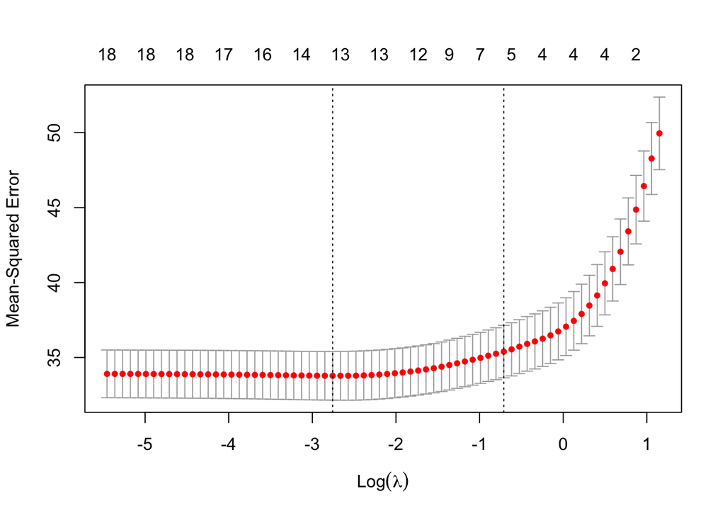

```r
plot(cv_model)
```

```r
best_model <- glmnet(as.matrix(x_train), as.matrix(y_train), alpha = 1, lambda = best_lambda)

y_predicted <- predict(best_model, as.matrix(x_train))
coef(best_model)
```

```
## 19 x 1 sparse Matrix of class "dgCMatrix"
##                                    s0
## (Intercept)             -1.147809e+02
## mean_pm25                7.598268e-02
## smoke                    6.156725e+00
## obese                    .
## poverty                  .
## no_grad                  2.129800e+01
## owner_occupied           3.084109e+00
## hispanic_pct             .
## blk_pct                  3.379687e+00
## age_pct_65_plus          1.333156e+01
## age_pct_45_65           -4.420689e+01
## age_pct_15_44           -2.241125e+01
## population_density       2.646521e-04
## median_household_income -3.151279e-05
## median_house_value      -1.086747e-05
## mean_summer_temp         4.818711e-01
## mean_winter_temp         .
## mean_summer_rm           .
## mean_winter_rm          -4.944100e-02
```

```r
#find SST and SSE
sst <- sum((y_test - mean(y_test))^2)
sse <- sum((y_predicted - y_test)^2)
y_predicted = predict(best_model, s = best_lambda, as.matrix(x_test))

#find R-Squared

R2(y_predicted, y_test)
```

```
##             s1
## [1,] 0.3284122
```

With all above models, we run into issues for a high performance model for numerical predictions. Next step will be to bin mortality and evaluate our covariates such as PM2.5 and others to determine if classification will be better.

## Running SVM for Binary Mortality prediction above or below median county values

```r
df <- df %>%
   mutate(Mortality_bin = ifelse(Mortality >= median(Mortality), 1, 0))
# resep train/test sets
index_train<- createDataPartition(y = df$Mortality_bin, times =1, p=0.8, list = FALSE)
train_set <- slice(df, index_train)
test_set <- slice(df, -index_train)

#used similar formula to LM section
model_svm_bin = svm(as.factor(Mortality_bin) ~ mean_pm25 +
                        scale(smoke) +
                        scale(obese) +
                        scale(poverty) +
                        scale(no_grad) +
                        scale(owner_occupied) +
                        scale(blk_pct) +
                        scale(hispanic_pct) +
                        scale(age_pct_65_plus) +
                        scale(age_pct_45_65) +
                        scale(age_pct_15_44) +
                        scale(log(population_density)) +
                        scale(log(median_household_income)) +
                        scale(log(median_house_value)) +
                        scale(mean_summer_temp) + scale(mean_winter_temp) + scale(mean_summer_rm) + scale(mean_winter_rm)
                        , data = train_set)

#Predict using SVM class
predYsvm_bin = predict(model_svm_bin, test_set, type = "response")

confusionMatrix(data = as.factor(predYsvm_bin), reference = as.factor(test_set$Mortality_bin))
```

```
## Confusion Matrix and Statistics
##
##           Reference
## Prediction   0   1
##          0 231  94
##          1  76 213
##
##                Accuracy : 0.7231
##                  95% CI : (0.6859, 0.7582)
##     No Information Rate : 0.5
##     P-Value [Acc > NIR] : <2e-16
##
##                   Kappa : 0.4463
##
##  Mcnemar's Test P-Value : 0.1923
##
##             Sensitivity : 0.7524
##             Specificity : 0.6938
##          Pos Pred Value : 0.7108
##          Neg Pred Value : 0.7370
##              Prevalence : 0.5000
##          Detection Rate : 0.3762
##    Detection Prevalence : 0.5293
##       Balanced Accuracy : 0.7231
##
##        'Positive' Class : 0
##
```

```r
model_svm_bin2 = svm(as.factor(Mortality_bin) ~ ., data = select(train_set, -c(Mortality)), preProcess = c("center","scale"))

#Predict using SVM
predYsvm_bin2 = predict(model_svm_bin2, test_set, type = "response")

#Calculate RMSE
predYsvm_bin2[1:10]
```

```
##     Blount, Alabama, US   Franklin, Alabama, US     Geneva, Alabama, US
##                       1                       1                       1
##     Greene, Alabama, US       Hale, Alabama, US Tallapoosa, Alabama, US
##                       1                       1                       1
##    Winston, Alabama, US   Greenlee, Arizona, US   Maricopa, Arizona, US
##                       1                       0                       1
##     Mohave, Arizona, US
##                       1
## Levels: 0 1
```

```r
confusionMatrix(data = as.factor(predYsvm_bin2), reference = as.factor(test_set$Mortality_bin), positive = '1')
```

```
## Confusion Matrix and Statistics
##
##           Reference
## Prediction   0   1
##          0 225  96
##          1  82 211
##
##                Accuracy : 0.7101
##                  95% CI : (0.6724, 0.7457)
##     No Information Rate : 0.5
##     P-Value [Acc > NIR] : <2e-16
##
##                   Kappa : 0.4202
##
##  Mcnemar's Test P-Value : 0.3299
##
##             Sensitivity : 0.6873
##             Specificity : 0.7329
##          Pos Pred Value : 0.7201
##          Neg Pred Value : 0.7009
##              Prevalence : 0.5000
##          Detection Rate : 0.3436
##    Detection Prevalence : 0.4772
##       Balanced Accuracy : 0.7101
##
##        'Positive' Class : 1
##
```

With all covariates included, the predictions naturally have a slightly lower performance. The specificity and sensitivity of the model, although, is quite balanced for the county predictions.

#### **Resources Visited for Code Reference:**

https://www.statology.org/lasso-regression-in-r/

https://towardsdatascience.com/effective-feature-selection-recursive-feature-elimination-using-r-148ff998e4f7

https://topepo.github.io/caret/train-models-by-tag.html#neural-network

https://www.kdnuggets.com/2017/03/building-regression-models-support-vector-regression.html

https://www.datatechnotes.com/2019/09/support-vector-regression-example-with.html